# Script de extracción y visualización de datos abiertos COVID-19 en Argentina.

Pedro Damian Orden

Actualizado: 23-08-2021

### Inicio

En base a los datos obtenidos del código de extracción presente en este [repo](https://github.com/pedroorden/codigodetrabajo), vamos generar 5 visuales sobre la pandemia en Argentina, trabajando con el recorte de afectados extraído del [SISA](https://sisa.msal.gov.ar/sisa/).

Como éste es un documento abierto con fines pedagógicos, la propuesta de cada vizualización es sintentizar una forma de organizar la información y con ello dar cuenta de diversos indicadores de la pandemia en nuestro país.

Avanzamos cargando las librerías y el set de datos que descargamos y guardamos con [fst](http://www.fstpackage.org/).

```r
library(tidyverse)
library(lubridate)
library(dplyr)
library(fst)
library(ggplot2)
library(glue)
options(scipen=1000)
ar_positivos <- read_fst("ar_positivos.fst")
```

```r
hist <- ar_positivos %>%
  ggplot(aes(ar_positivos$fecha)) +
  geom_histogram(col="steelblue", aes(fill=..count..))+
  scale_fill_gradient2(low='darkgreen', mid='steelblue',
                       high='darkblue', midpoint=6,
                       name='ar_positivos')+
  labs(title =
  "Afectación COVID-19 en Argentina agrupada por mes (20/21)",
       x= "Referencia temporal 20/21",
       y= "Afectados mensuales.")+
  guides(fill=guide_legend(title="Ref a/mensuales"), colour =
        guide_legend(reverse=F))+
  theme_bw() +
  theme(plot.title = element_text(hjust = 0.5, size = 8.4,
                     lineheight=.7,face="bold"),
    axis.text.x = element_text(angle = 45, size = 8),
    axis.title.x = element_text(size = 8),
    axis.title.y = element_text(size = 8),
    legend.title = element_text(color = "black", size = 8),
    legend.text = element_text(angle = 45,
      color = "black", size = 8),legend.position="bottom")
```

Inmprimimos:

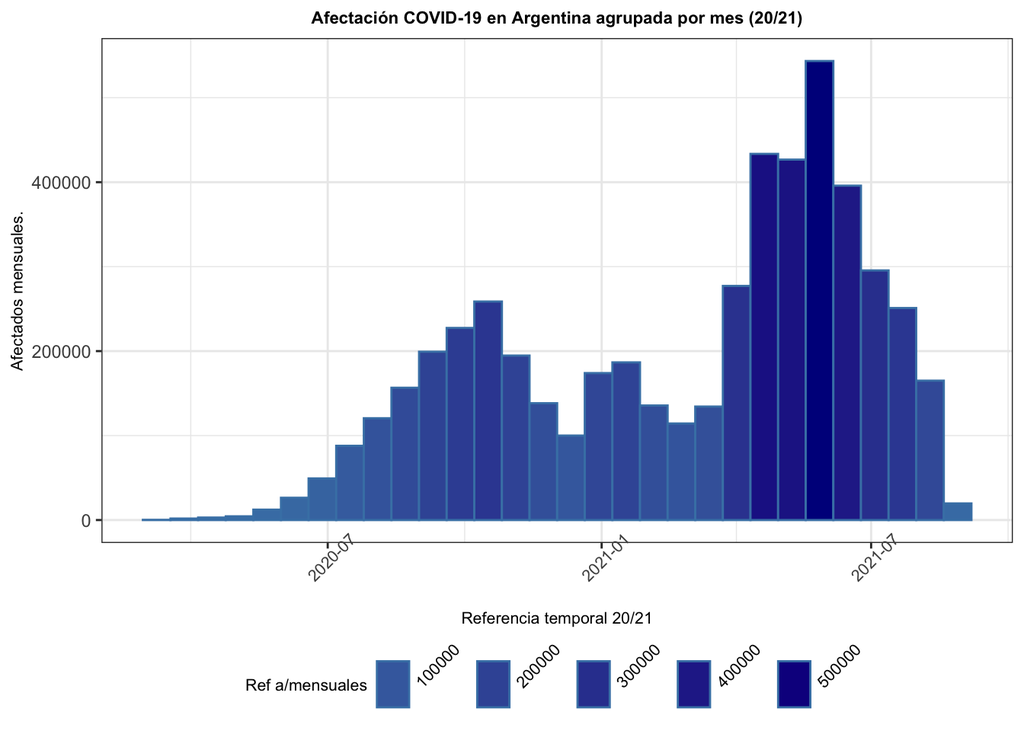

```r
hist
```

Con esta primera visual de la afectación COVID-19 en clave temporal se pueden apreciar claramente las denominadas primera y segunda “ola de contagios” en los años 2020 y 2021 respectivamente en la Argentina.

### Enriqueciendo los datos

Una vez que tenemos el primer recorte de los datos, vamos crear nuevas variables ponderadas para enriquecer nuestro abordaje. Calcular la incidencia y mortalidad por 100.000 habitantes junto con la letalidad son operaciones relevantes para pensar el impacto del virus en un territorio determinado y compararlo con otros.

Para el caso presentado nos interesa nos interesa hacer un desagregado a escala federal. Para eso vamos a utilizar un vector con datos poblacionales por provincia que coadyuvará al enriquecimiento de nuestra información.

Levantamos el vector con los datos de población:

```r
master <-read_csv("master.csv")
```

Generamos nuestro código con los nuevos estadísticos;

```r
provinciascovid <- ar_positivos %>%
  group_by(provincia) %>%
  summarise(casos = n(),
            fallecimientos = sum(fallecido=='SI'),
            intensivos = sum(cuidado_intensivo =='SI'),
            asistencia_respi =
  sum(asistencia_respiratoria_mecanica=='SI'),
            letalidad = fallecimientos/casos * 100)%>%
  left_join(master)%>%
  mutate(casosmil = 1e5*casos/poblacion,
         muertesmil = 1e5*fallecimientos/poblacion)
```

De esta forma ya podemos acceder a los principales estadísticos epidemiológicos por provincia: afectados, fallecidos, variables ponderadas, etc.

### Imágenes de la pandemia…

Detengamonos inicialmente en el caso de los datos acumulados de afectados e incidencia del virus COVID-19 cada 100.000 habitantes por provincia argentina.

Armamos nuestro gráfico de afectados:

```r
plot1 <- provinciascovid %>%
  select(provincia, casos)%>%
  mutate_if(is.numeric, round, digits=1)%>%
  filter(!provincia=="SIN ESPECIFICAR") %>%
  arrange(desc(casos))%>%
  ggplot(aes(reorder(provincia,casos),
             casos, fill = casos)) +
  geom_bar(stat = 'identity', alpha=0.9) +
  scale_fill_viridis_c(option = "viridis") +
  geom_label(aes(label=casos), fontface = "bold",
             color ="grey",
             size=2 ,position=position_dodge(width=0),
             vjust=0.0)+
  coord_flip()+
  labs(title = "Afectados COVID-19 acumulados 20/21",
       x= "Provincias Argentinas",
       y= "Afectados",
       fill = "Ref:")
```

Lo vemos;

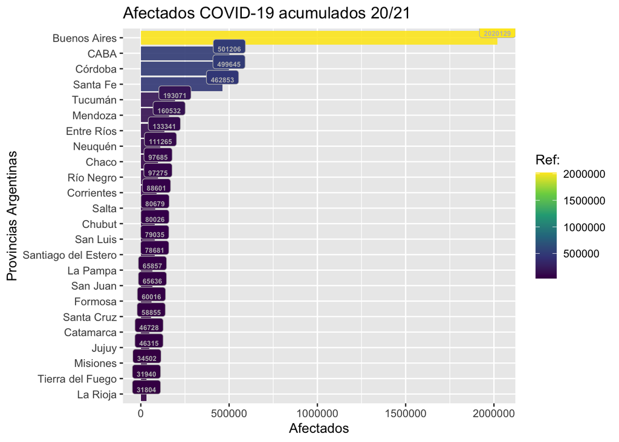

```r
plot1
```

Ahora, repetimos el proceso con la variable de incidencia COVID-19 por 100.000 habitantes. En este caso vamos a darle un mejor formato al gráfico:

```r
plot2 <- provinciascovid %>%
  select(provincia, casosmil)%>%
  mutate_if(is.numeric, round, digits=1)%>%
  filter(!provincia=="SIN ESPECIFICAR") %>%
  arrange(desc(casosmil))%>%
  ggplot(aes(reorder(provincia,casosmil),
             casosmil, fill = casosmil)) +
  geom_bar(stat = 'identity', alpha=0.9) +
  scale_fill_viridis_c(option = "cividis") +
  geom_label(aes(label=casosmil), fontface = "bold",
  color ="white",
  size=2 ,position=position_dodge(width=0.1), vjust=0.0)+
  coord_flip()+
  labs(title =
"Afectados COVID-19 acumulados cada 100.000 abitantes(20/21)",
       x= "Provincias Argentinas",
       y= "Afectados c/100.000 habitantes",
       fill = "Ref:") +
  theme(plot.title = element_text(hjust = 0.5,
        size = 11, lineheight=.7, face="bold"),
        plot.subtitle = element_text(hjust = 0.5,   size = 9,
        lineheight=.7, face="bold"),
    axis.text.x = element_text(angle = 45, size = 8),
    axis.title.x = element_text(size = 8),
    axis.title.y = element_text(size = 8),
    legend.title = element_text(color = "black",
    size = 8),legend.text = element_text(color = "black",
    size = 8),legend.position="right")
```

Y lo mostramos:

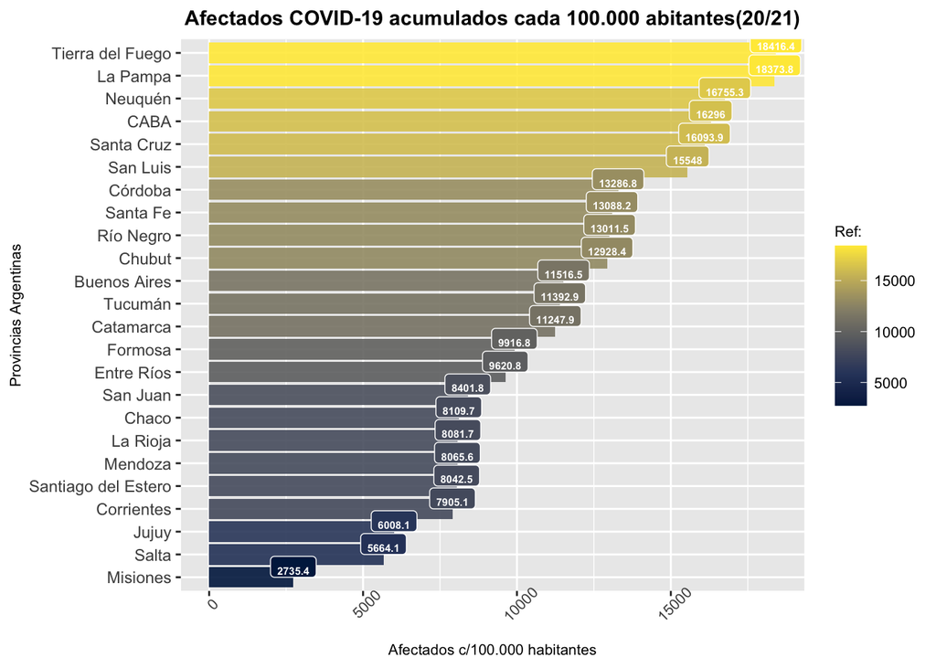

```r
plot2
```

La lectura comparada de ambas gráficas da cuenta, por ejemplo, de una clara diferencia entre el ordenamiento de provincias que deviene al computar la afectación nominal o bien la ponderación por cien mil habitantes. Tengamos presente que depende de nuestros objetivos de investigación la eleccion de una, otra, o más variables.

Para seguir abriendo posibles ángulos de indagación con nuestros datos, vamos a reorganizarlos en clave espacio-temporal y poner nuestro foco en el promedio de edad de contagio diario del virus, prestando particular atención a las 4 provincias argentinas con más afectados (en términos nominales).

Armamos la data con los cortes y filtros que son de nuestro interés:

```r
edad_afectados <- ar_positivos%>%
  filter(!provincia=="SIN ESPECIFICAR") %>%
  group_by(provincia, fecha)%>%
  summarise(casos = n(),
            muertos = sum(fallecido=='SI'),
            edad_promedio = mean(edad, na.rm=T))%>%
              mutate_if(is.numeric, round, digits=1)%>%
  select(fecha, provincia, edad_promedio)%>%
  filter(provincia%in%c("CABA", "Buenos Aires",
                        "Santa Fe", "Córdoba"))
```

Generamos el gráfico:

```r
plot_afectados <- edad_afectados %>%
  ggplot(aes(x = fecha, y = edad_promedio)) +
  geom_line(size = 0.1, alpha = 1)+
  labs(title =
"Promedio diario de edad de los afectados por causas COVID-19",
       x= "Referencia temporal",
       y= "Edad promedio")+
  theme_bw() +
  facet_wrap(.~provincia, scales = "free")
```

…y lo imprimimos en pantalla:

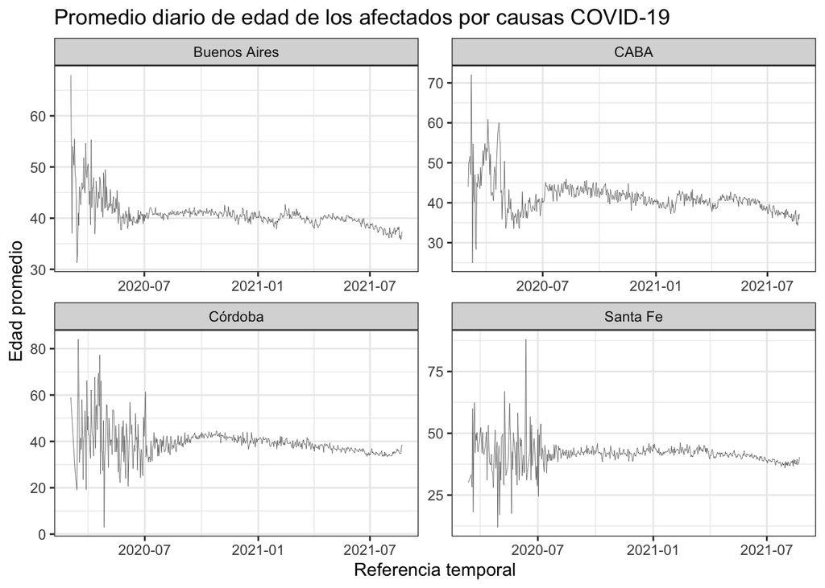

```r
plot_afectados
```

A primera vista vemos una baja progresiva en el promedio de edad contagio desde inicio de la pandemia a la fecha en las 4 provincias, siendo Buenos Aires la que presenta el menor promedio de edad (observar en la imagen como se reduce la escala el eje Y en BA particularmente).

Para hacer un zoom en el tema etáreo vamos a deternernos en la distribución porcentual de los afectados por grupo de edad, trabajaremos en este caso con variables factoriales.

Para dar con nuestro cometido vamos a generar una nueva variable **“grupo de edad”** a partir de los datos de edad que tenemos.

```r
grupo_etareo <- ar_positivos%>%
  filter(!provincia=="SIN ESPECIFICAR") %>%
  filter(provincia %in% c("Buenos Aires",
                          "CABA", "Santa Fe",
                          "Córdoba"))%>%
    mutate(grupoedad = case_when(
      edad == NA ~ "sin datos",
      edad >= -20 & edad <= 19 ~ "de 0 a 19 años",
      edad >= 20 & edad <= 40 ~ "de 20 a 40 años",
      edad >= 41 & edad <= 59 ~ "de 41 a 59 años",
      edad >= 60 & edad <= 150 ~ "de 60 años en adelante")) %>%
  ungroup() %>%
  filter(!grupoedad=="sin datos") %>%
  group_by(provincia,grupoedad) %>%
  summarise(casos = n()) %>%
  group_by(provincia) %>%
  mutate(casost=sum(casos),
         pct=casos/casost*100) %>%
  mutate_if(is.numeric, round, digits=1)

grupo_etareo$grupoedad[is.na(grupo_etareo$grupoedad)]<- "sin datos"

grupo_etareo$grupoedad<-as_factor(grupo_etareo$grupoedad)

grupo_etareo$provincia<-as_factor(grupo_etareo$provincia)
```

El script de nuestro plot;

```r
plot_grup <- grupo_etareo%>%
  ggplot(aes(fill=grupoedad, y=pct, x=provincia, label = pct)) +
  geom_bar(stat="identity") +
  scale_fill_viridis_d(option = "viridis") +
  geom_text(size = 3,fontface = "bold",
            color ="white",
            position = position_stack(vjust = 0.5)) +
  theme_bw() +
  labs(title =
  "Afectados COVID-19 por provincia y grupo etáreo",
       x= "Provincia",
       y= "% de afectados por grupo de edad",
       fill="Grupo etáreo")
```

Visualizamos:

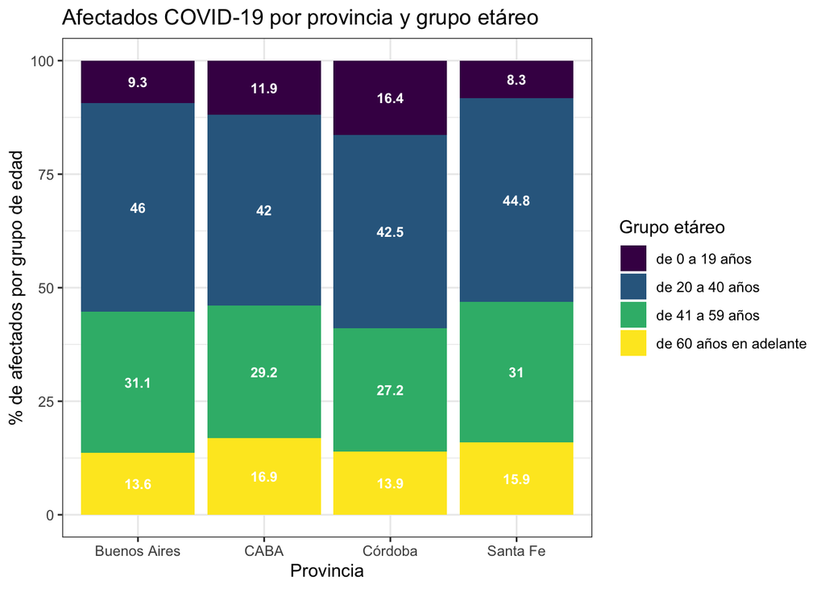

```r
plot_grup
```

### Palabras Finales

Lo que hemos visto hasta aquí son recortes de experiencias prácticas del trabajo con datos, muchos de estos códigos sintetizan largos debates teóricos, metodológicos, estadísticos y tiempos de búsqueda de información sobre funciones y paquetes de R y afines.

Se ha procurado dar cuenta, de manera sucinta, de una serie de procedimientos y criterios para la manipulación y exploración de datos abiertos que bien pueden replicarse con otros sets y experiencias de desarrollo. Se espera que este documento opere como guía pedagogica en dicho sentido.

Cabrá destacar especialmente el uso y la importancia del paquete fst para gestionar con notable rapidez archivos de grandes dimensiones, habida cuenta, sobre todo, de la cualidad de objeto COVID-19 que se expande de manera constante.

Por ultimo, puede consultarse una [shiny](https://idepsalud21.shinyapps.io/MonitorCOVID19_021/) que desarollé para IDEP y opera con la misma logica que vimos en este documento.